# Práctica 3. Preparación de Datos

Tratamiento de Datos, Grado en Ciencia de Datos - UV

Carlos Santiago Martinez Torres

2025-03-12

# Introducción

El objetivo de esta práctica es preparar los datos de una manera estructurada. Para ello vamos a seguir las recomendaciones del artículo de Hadley Wickham, *Tidy Data*, donde nos muestra una forma de estructurar (u organizar) los datos, de manera que se faciliten posteriores cadenas de procesado (visualización, obtención de datos estadísticos, modelización, etc.).

Decimos que un conjunto de datos está estructurado u organizado (se usa el término *tidy* en inglés) cuando cumple estas tres condiciones:

1. Cada variable está en una columna.
2. Cada observación está en una fila.
3. Cada unidad de observación está en una tabla.

Por el contrario, si no se cumple cualquiera de estas tres condiciones decimos que los datos están desordenados (*messy*).

Parece fácil, pero el problema viene al definir exactamente qué es lo que entendemos por variables y observaciones.

- Una variable (columna) contiene los valores correspondientes a un atributo (ej. altura, tiempo, etc.).
- Una observación (fila) contiene los valores medidos sobre la misma unidad (una persona, una fecha, una muestra etc.) a lo largo de los atributos.

Vamos a ver un ejemplo con el dataset IRIS.

```r
head(iris)
```

```
  Sepal.Length Sepal.Width Petal.Length Petal.Width Species
1          5.1         3.5          1.4         0.2  setosa
2          4.9         3.0          1.4         0.2  setosa
3          4.7         3.2          1.3         0.2  setosa
4          4.6         3.1          1.5         0.2  setosa
5          5.0         3.6          1.4         0.2  setosa
6          5.4         3.9          1.7         0.4  setosa
```

¿Es un conjunto *tidy*?

- ¿Cada variable está en una columna? Depende de lo que definamos como variable. Según hemos visto, una variable debería contener todos los valores que miden un atributo. En este caso el atributo `Width` aparece en dos columnas, `Sepal.Width` y `Petal.Width`. Lo mismo ocurre con `Length`. También las partes de la flor: `Sepal` y `Petal` aparecen en varias columnas.
- ¿Cada fila es una única observación?

Veamos que aspecto tiene el conjunto IRIS una vez estructurado:

```r
load('data/iris_tidy.Rdata')
head(iris.tidy)
```

```
  Species  Part Measure Value
1  setosa Sepal  Length   5.1
2  setosa Sepal  Length   4.9
3  setosa Sepal  Length   4.7
4  setosa Sepal  Length   4.6
5  setosa Sepal  Length   5.0
6  setosa Sepal  Length   5.4
```

Como se puede observar, en la versión *tidy* se han reorganizado los datos de manera que todos los valores medidos en una misma unidad ocupan una única columna. Para ello se han creado dos nuevas columnas correspondientes a dos nuevas variables, `Part`, que indica si se trata de `Sepal` o `Petal`, y `Measure`, que indica si se ha medido `Length` o `Width`.

## Librería `tidyr`: organización de datos en tablas

Para ayudarnos en la tarea de estructurar los datos según este formato *tidy*, en R se dispone de la librería `tidyr`. Consulta el *cheatsheet* `data-import.pdf` para ver cuáles son las funciones más importantes de esta librería. En esta práctica veremos sobretodo las siguientes:

- `gather(data, key, value, ...)`: permite agrupar o juntar varias columnas en una sola en función de una misma clave (`key`) que toma los valores de los encabezados de las columnas agrupadas, y una columna `value` toma los valores de sus celdas.
- `spread(data, key, value, ...)`: hace lo contrario que `gather`, divide o esparce los valores que toma una variable dada por `key`/`value` como nuevas columnas cuyos nombres son los valores de `key`.
- `separate(data, col, into, ...)`: separa los contenidos que hay en una columna en varias columnas sin cambiar el número de observaciones (no confundir con `spread`).
- `unite(data, col, ...)`: hace lo contrario de `separate`, junta los contenidos de varias columnas (no confundir con `gather`).

Aunque `gather` y `spread` se siguen utilizando, existen dos nuevas funciones de `tidyr` que tienen un comportamianto similar:

- `pivot_longer(data, cols, names_to, values_to)`: condensa la información de las columnas `cols` en dos, dadas por los valores de sus encabezados (`names_to`), y los contenidos de sus celdas (`values_to`).
- `pivot_wider(data, names_from, values_from)`: es el caso inverso: extiende las columnas dadas por `names_from` y `values_from` a tantas columnas como valores tome la variable `names_from`.

También son interesantes las siguientes:

- `drop_na(data, ...)`: elimina las filas que contienen NA’s.
- `fill(data, ...)`: sustituye los NA’s por el valor más reciente no NA.
- `replace_na(data, replace=list(), ...)`: reemplaza los NA’s con los valores suministrados.

Volviendo al ejemplo del dataset IRIS, veamos cómo podemos usar `gather` y `separate` para convertir el conjunto original `iris` en el conjunto `iris.tidy`.

```r
library(tidyr)
# Primero agrupamos todas las unidades
# Agrupamos todas las columnas con datos excepto Species, que está bien
# iris.t <- gather(data=iris, key="Part", value="Value", 1:4)
iris.t <- gather(iris, Part, Value, -Species)
head(iris.t)
```

```
  Species         Part Value
1  setosa Sepal.Length   5.1
2  setosa Sepal.Length   4.9
3  setosa Sepal.Length   4.7
4  setosa Sepal.Length   4.6
5  setosa Sepal.Length   5.0
6  setosa Sepal.Length   5.4
```

```r
# Luego separamos la variable Part en dos, Part y Measure
iris.t <- separate(iris.t, Part, into=c("Part", "Measure"))
head(iris.t)
```

```
  Species  Part Measure Value
1  setosa Sepal  Length   5.1
2  setosa Sepal  Length   4.9
3  setosa Sepal  Length   4.7
4  setosa Sepal  Length   4.6
5  setosa Sepal  Length   5.0
6  setosa Sepal  Length   5.4
```

Ahora ya tiene formato *tidy*. Cada columna contiene una variable, y cada fila una observación.

Podemos hacer lo mismo con `pivot_longer`. Observa como cambia la ordenación de las filas.

```r
iris.t.2 <- pivot_longer(iris, col=-Species, names_to="Part", values_to="Value")
head(iris.t.2)
```

```
# A tibble: 6 × 3
  Species Part         Value
  <fct>   <chr>        <dbl>
1 setosa  Sepal.Length   5.1
2 setosa  Sepal.Width    3.5
3 setosa  Petal.Length   1.4
4 setosa  Petal.Width    0.2
5 setosa  Sepal.Length   4.9
6 setosa  Sepal.Width    3
```

```r
# Luego separamos la variable Part en dos, Part y Measure
iris.t.2 <- separate(iris.t.2, Part, into=c("Part", "Measure"))
head(iris.t.2)
```

```
# A tibble: 6 × 4
  Species Part  Measure Value
  <fct>   <chr> <chr>   <dbl>
1 setosa  Sepal Length    5.1
2 setosa  Sepal Width     3.5
3 setosa  Petal Length    1.4
4 setosa  Petal Width     0.2
5 setosa  Sepal Length    4.9
6 setosa  Sepal Width     3
```

## Librería `magrittr`: ceci n’est pas une pipe

Como habrás observado, para conseguir formatear el conjunto `iris` hemos tenido que aplicar dos operaciones, `gather` y `separate`. Esto nos ha obligado a tener que crear una variable, `iris.t`, donde almacenar el resultado de `gather`, para luego pasárselo a `separate`. También podríamos haber hecho algo como:

```r
iris.t <- separate(gather(iris, Part, Value, -Species),
                   Part, into=c("Part", "Measure"))
head(iris.t)
```

```
  Species  Part Measure Value
1  setosa Sepal  Length   5.1
2  setosa Sepal  Length   4.9
3  setosa Sepal  Length   4.7
4  setosa Sepal  Length   4.6
5  setosa Sepal  Length   5.0
6  setosa Sepal  Length   5.4
```

Pero queda algo confuso, y aún lo es más cuando en lugar de dos operaciones hemos de realizar varias seguidas.

Una alternativa es usar la librería `magrittr` que define el operador `%>%` que permite encadenar este tipo acciones. El concepto es que los datos pasan de una función a otra como a través de una tubería (*pipe* en inglés) de funciones. Veamos cómo queda nuestro ejemplo:

```r
iris.t <- gather(iris, Part, Value, -Species) %>% separate(Part, into=c("Part", "Measure"))
iris.t %>% head
```

```
  Species  Part Measure Value
1  setosa Sepal  Length   5.1
2  setosa Sepal  Length   4.9
3  setosa Sepal  Length   4.7
4  setosa Sepal  Length   4.6
5  setosa Sepal  Length   5.0
6  setosa Sepal  Length   5.4
```

## Ejemplo de visualización

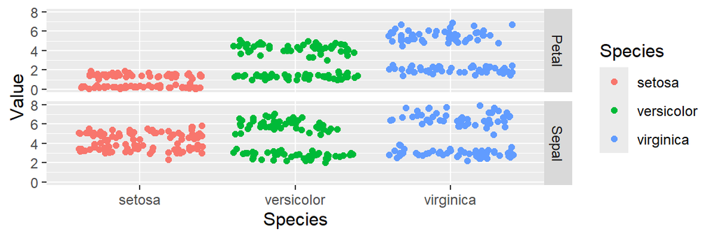

```r
library(ggplot2)
ggplot(iris.t) + aes(Species, Value, color=Species) +
  geom_jitter() + facet_grid(Part ~ .)
```

En los siguientes ejercicios veremos los ejemplos más típicos de datos desorganizados, o *messy data*:

- Las cabeceras de las columnas son variables en sí mismas, no nombres de variables.
- Más de una variable aparece en una sola columna.
- Las variables aparecen tanto en filas como en columnas.
- Varias unidades de observación están almacenadas en una única tabla.
- Una única unidad de observación está almacenada en varias tablas.

**Pregunta**: ¿qué tipo de problema(s) de los mencionados aquí presenta el conjunto IRIS original?

```r
# En el conjunto Iris original, las cabeceras de las columnas son nombres de las variables, por lo que más de una variable aparece en una sola columna. Esto hace que las variables aparezcan tanto en filas como en columnas.
```

# Las cabeceras de las columnas son variables en lugar de nombres de variables

El siguiente conjunto de datos muestra la relación entre los ingresos y la religión en EEUU.

```r
print(load('data/pew_religion.Rdata'))
```

```
[1] "pew_religion"      "pew_religion_tidy"
```

```r
head(pew_religion[, 1:10])
```

```
            religion <$10k $10-20k $20-30k $30-40k $40-50k $50-75k $75-100k $100-150k >150k
1           Agnostic    27      34      60      81      76     137      122       109    84
2            Atheist    12      27      37      52      35      70       73        59    74
3           Buddhist    27      21      30      34      33      58       62        39    53
4           Catholic   418     617     732     670     638    1116      949       792   633
5 Don’t know/refused    15      14      15      11      10      35       21        17    18
6   Evangelical Prot   575     869    1064     982     881    1486      949       723   414
```

Como se ve, las cabeceras son valores de una variable de tipo factor (los ingresos) en lugar de nombres de variables.

Este conjunto de datos tiene en realidad tres variables, que deberían estar en tres columnas: `religion`, `ingresos` y `frecuencia` (esta última con el número de casos).

Para ver la utilidad de organizar los datos en formato *tidy*, imagina que quisieramos realizar un gráfico donde se mostrara la cantidad de gente por cada intervalo de ingresos.

**¿Cómo lo harías con el conjunto original?**

Fíjate que este gráfico es mucho más fácil de realizar si en lugar de tener los intervalos de ingresos repartidos en columnas los tuvieramos como una variable.

Para convertir este conjunto a formato *tidy* tendremos que agrupar todas las columnas excepto la de `religion` en dos, una llamada `income` con los intervalos de ingresos, y otra llamada `freq` con el número de casos para cada `income`. Como ya hemos visto en el ejemplo del conjunto IRIS, esto se consigue con `gather`.

```r
head(pew_religion) # Formato inicial
```

```
            religion <$10k $10-20k $20-30k $30-40k $40-50k $50-75k $75-100k $100-150k >150k
1           Agnostic    27      34      60      81      76     137      122       109    84
2            Atheist    12      27      37      52      35      70       73        59    74
3           Buddhist    27      21      30      34      33      58       62        39    53
4           Catholic   418     617     732     670     638    1116      949       792   633
5 Don’t know/refused    15      14      15      11      10      35       21        17    18
6   Evangelical Prot   575     869    1064     982     881    1486      949       723   414
  Don't know/refused
1                 96
2                 76
3                 54
4               1489
5                116
6               1529
```

```r
niveles <- rev(colnames(dplyr::select(pew_religion, -religion))) # Obtenemos los nombres de las columnas para determinar los niveles del factor Income

religion <- pew_religion %>%
  gather(key="Income", value= "Frecuencia", -religion) %>%
  arrange(religion) %>%
  mutate(Income = factor(Income, levels = niveles, ordered = TRUE))

head(religion) # Observamos el conjunto tidy
```

```
  religion  Income Frecuencia
1 Agnostic   <$10k         27
2 Agnostic $10-20k         34
3 Agnostic $20-30k         60
4 Agnostic $30-40k         81
5 Agnostic $40-50k         76
6 Agnostic $50-75k        137
```

```r
levels(religion$Income) # Verificamos el orden de los niveles
```

```
 [1] "Don't know/refused" ">150k"              "$100-150k"          "$75-100k"
 [5] "$50-75k"            "$40-50k"            "$30-40k"            "$20-30k"
 [9] "$10-20k"            "<$10k"
```

Otro ejemplo usando el conjunto de datos `Billboard` que muestra cuando una canción entró en el top 100.

```r
load('data/billboard.Rdata')
head(raw[, 1:12])
```

```
  year       artist                   track time date.entered wk1 wk2 wk3 wk4 wk5 wk6 wk7
1 2000        2 Pac          Baby Don't Cry 4:22   2000-02-26  87  82  72  77  87  94  99
2 2000      2Ge+her The Hardest Part Of ... 3:15   2000-09-02  91  87  92  NA  NA  NA  NA
3 2000 3 Doors Down              Kryptonite 3:53   2000-04-08  81  70  68  67  66  57  54
4 2000 3 Doors Down                   Loser 4:24   2000-10-21  76  76  72  69  67  65  55
5 2000     504 Boyz           Wobble Wobble 3:35   2000-04-15  57  34  25  17  17  31  36
6 2000          98? Give Me Just One Nig... 3:24   2000-08-19  51  39  34  26  26  19   2
```

La posición (*ranking*) de cada canción en cada semana después de haber entrado en el Top 100 se almacena en las columnas `wk1` a `wk76` (ver `str(raw)`). Si un tema sale del Top 100 antes de 76 semanas se rellenan los datos con NA’s.

Para obtener la versión *tidy* hemos de juntar todas las columnas desde `wk1` a `wk76` asignando como clave (`key`) una variable de nombre `week`, como valor (`value`) otra variable de nombre `rank`.

**Ejercicio 2** Obtén la versión *tidy* de este conjunto de datos usando `pivot_longer`.

Consejo: puedes eliminar el prefijo `wk` de las semanas mediante el argumento `names_prefix`. Opcionalmente puedes crear una columna `date` a partir de `date.entered`, sumando las semanas transcurridas desde la fecha de entrada en lista.

```r
rankings <- raw %>%
  select(-year) %>% # Ya que todos los valores de year = 200
  pivot_longer(names_to='week', values_to='rank', cols= -c(1:4), names_prefix='wk') %>%
  mutate(week = as.numeric(week)) %>%
  mutate(date = as.Date(date.entered, format="%Y-%m-%d") + (week*7)) # Usando la libreria lubridate.

rankings
```

```
# A tibble: 24,092 × 7
   artist track          time  date.entered  week  rank date
   <chr>  <chr>          <chr> <chr>        <dbl> <int> <date>
 1 2 Pac  Baby Don't Cry 4:22  2000-02-26       1    87 2000-03-04
 2 2 Pac  Baby Don't Cry 4:22  2000-02-26       2    82 2000-03-11
 3 2 Pac  Baby Don't Cry 4:22  2000-02-26       3    72 2000-03-18
 4 2 Pac  Baby Don't Cry 4:22  2000-02-26       4    77 2000-03-25
 5 2 Pac  Baby Don't Cry 4:22  2000-02-26       5    87 2000-04-01
 6 2 Pac  Baby Don't Cry 4:22  2000-02-26       6    94 2000-04-08
 7 2 Pac  Baby Don't Cry 4:22  2000-02-26       7    99 2000-04-15
 8 2 Pac  Baby Don't Cry 4:22  2000-02-26       8    NA 2000-04-22
 9 2 Pac  Baby Don't Cry 4:22  2000-02-26       9    NA 2000-04-29
10 2 Pac  Baby Don't Cry 4:22  2000-02-26      10    NA 2000-05-06
# ℹ 24,082 more rows
```

# Varias variables en una misma columna

El conjunto de datos `tuberculosis`, de la *World Health Organization*, presenta este tipo de desordenación (además de la vista en el apartado anterior). Muestra el número de casos de tuberculosis por país, año y grupo demográfico. Estos grupos demográficos se muestran en los nombres de las columnas como `m` o `f` (sexo) y la edad (0-14, 15-24, 25-34, 35-44, 45-54, 55-64, 65- y desconocido (`u`)).

```r
load('data/tb.Rdata')
head(raw[, 1:16])
```

```
    country year m014 m1524 m2534 m3544 m4554 m5564 m65 mu f014 f1524 f2534 f3544 f4554 f5564
11       AD 2000    0     0     1     0     0     0   0 NA   NA    NA    NA    NA    NA    NA
37       AE 2000    2     4     4     6     5    12  10 NA    3    16     1     3     0     0
61       AF 2000   52   228   183   149   129    94  80 NA   93   414   565   339   205    99
88       AG 2000    0     0     0     0     0     0   1 NA    1     1     1     0     0     0
137      AL 2000    2    19    21    14    24    19  16 NA    3    11    10     8     8     5
166      AM 2000    2   152   130   131    63    26  21 NA    1    24    27    24     8     8
```

Podemos ver como efectivamente en una columna tenemos dos variables juntas, el sexo y el rango de edad. Por ejemplo, en `m014` la `m` hace referencia al sexo y `014` al rango de edad, dos variables que deberían estar separadas.

Para pasar a formato *tidy* necesitamos realizar dos operaciones en este caso. En la primera juntaremos todas las columnas `m...` y `f...` y los conteos (los llamaremos `casos`). En la segunda, separaremos las columnas con los datos de tipo `m014` en dos columnas, `sexo` y `edad`.

**Ejercicio 3** Convierte el conjunto de datos TB en *tidy* utilizando `pivot_longer` sin emplear `separate`.

```r
TB <- raw %>%
  pivot_longer(names_to='Caso', values_to='Conteo', cols= -c(1:2)) %>%
  extract(Caso, into = c("Sexo", "Edad"), regex = "([a-z])(\\d+)")

TB
```

```
# A tibble: 3,216 × 5
   country  year Sexo  Edad  Conteo
   <chr>   <int> <chr> <chr>  <int>
 1 AD       2000 m     014        0
 2 AD       2000 m     1524       0
 3 AD       2000 m     2534       1
 4 AD       2000 m     3544       0
 5 AD       2000 m     4554       0
 6 AD       2000 m     5564       0
 7 AD       2000 m     65         0
 8 AD       2000 <NA>  <NA>      NA
 9 AD       2000 f     014       NA
10 AD       2000 f     1524      NA
# ℹ 3,206 more rows
```

# Variables almacenadas tanto en filas como en columnas

Esta es la forma más complicada de datos desordenados, y es lo que ocurre en el conjunto de datos del *Global Historical Climatology Network*. Se muestra el tiempo para la estación `MX17004`, en México, durante 5 meses del año 2010.

```r
load('data/weather.Rdata')
head(raw[, 1:20])
```

```
       id year month element d1   d2   d3 d4   d5 d6 d7 d8 d9  d10  d11 d12 d13 d14 d15  d16
1 MX17004 2010     1    tmax NA   NA   NA NA   NA NA NA NA NA   NA   NA  NA  NA  NA  NA   NA
2 MX17004 2010     1    tmin NA   NA   NA NA   NA NA NA NA NA   NA   NA  NA  NA  NA  NA   NA
3 MX17004 2010     2    tmax NA 27.3 24.1 NA   NA NA NA NA NA   NA 29.7  NA  NA  NA  NA   NA
4 MX17004 2010     2    tmin NA 14.4 14.4 NA   NA NA NA NA NA   NA 13.4  NA  NA  NA  NA   NA
5 MX17004 2010     3    tmax NA   NA   NA NA 32.1 NA NA NA NA 34.5   NA  NA  NA  NA  NA 31.1
6 MX17004 2010     3    tmin NA   NA   NA NA 14.2 NA NA NA NA 16.8   NA  NA  NA  NA  NA 17.6
```

Como se observa, además de las variables `id`, `year` y `month`, tiene variables en las columnas `d1` a `d31` que deberían corresponder a una única variable `dia`, y en las filas, `tmin` y `tmax` deberían estar como columnas. Fíjate además que la columna `element` no es una variable, sino que almacena nombres de variables.

Para obtener la versión *tidy* primero juntamos todos los días en una variable `dia`. Luego tendremos que separar la columna `element` en dos columnas, `tmax` y `tmin`. Esto último lo lograremos con la función `pivot_wider` de tidyr, que no hemos utilizado hasta ahora.

**Ejercicio 4** Obtén la versión *tidy* del conjunto de datos `weather` utilizando las funciones `pivot_longer` y `pivot_wider`. Además cambiaremos las columnas `year`, `month` y `dia` por una única variable `fecha`, usando una funcion adecuada de la librería `lubridate`. Para que la operación `pivot_wider` no dé error tendremos que eliminar los NA’s cuando usemos `pivot_longer`.

```r
Weather <- raw %>%
  pivot_longer(names_to='dia', values_to='temp', cols=-(1:4), names_prefix='d') %>%
  drop_na(temp) %>%
  pivot_wider(names_from=element, values_from=temp) %>%
  unite(fecha, c(year:dia), sep='-') %>%
  mutate(fecha= as.Date(fecha, format="%Y-%m-%d"))

Weather
```

```
# A tibble: 33 × 4
   id      fecha       tmax  tmin
   <chr>   <date>     <dbl> <dbl>
 1 MX17004 2010-01-30  27.8  14.5
 2 MX17004 2010-02-02  27.3  14.4
 3 MX17004 2010-02-03  24.1  14.4
 4 MX17004 2010-02-11  29.7  13.4
 5 MX17004 2010-02-23  29.9  10.7
 6 MX17004 2010-03-05  32.1  14.2
 7 MX17004 2010-03-10  34.5  16.8
 8 MX17004 2010-03-16  31.1  17.6
 9 MX17004 2010-04-27  36.3  16.7
10 MX17004 2010-05-27  33.2  18.2
# ℹ 23 more rows
```

# Varias unidades de observación en una sola tabla

Volvemos al ejemplo del conjunto `Billboard` para ilustrar este caso. Si nos fijamos en la versión *tidy* que hemos obtenido en el ejercicio 2 vemos como `artist` y `time` se repiten para cada canción (`track`) y semana. Para evitar estas repeticiones hemos de dividir el dataframe en dos, uno de canciones donde almacenaremos el artista, el nombre de la canción y el tiempo, y otro con el *ranking* de canciones que nos dará la posición en el Top 100, la canción y la semana. A esta división de los datos en varias tablas para evitar duplicados se le llama *normalización*, y es habitual cuando estamos trabajando con datos almacenados en bases de datos, si bien no lo es tanto en el campo del análisis de datos, donde muchas veces para analizarlos se requiere volver a juntar de nuevo los datos en una única tabla.

**Ejercicio 5** Separa los datos *tidy* que teníamos en el ejercicio 2 en dos tablas (data frames) tal y como se describe en el párrafo anterior y empleando la función `unique` para eliminar repeticiones.

Opcionalmente se puede crear un identificador, `id`, asociado al nombre de la canción (`track`), y en la tabla de ranking solo usaremos este identificador en lugar del nombre de la canción.

```r
Songs <- rankings %>%
  select(artist, track, date.entered) %>%
  unique() %>%
  mutate(id = row_number())

Songs
```

```
# A tibble: 317 × 4
   artist         track                   date.entered    id
   <chr>          <chr>                   <chr>        <int>
 1 2 Pac          Baby Don't Cry          2000-02-26       1
 2 2Ge+her        The Hardest Part Of ... 2000-09-02       2
 3 3 Doors Down   Kryptonite              2000-04-08       3
 4 3 Doors Down   Loser                   2000-10-21       4
 5 504 Boyz       Wobble Wobble           2000-04-15       5
 6 98?            Give Me Just One Nig... 2000-08-19       6
 7 A*Teens        Dancing Queen           2000-07-08       7
 8 Aaliyah        I Don't Wanna           2000-01-29       8
 9 Aaliyah        Try Again               2000-03-18       9
10 Adams, Yolanda Open My Heart           2000-08-26      10
# ℹ 307 more rows
```

```r
Ranks <- rankings %>%
  select(rank, track, week) %>%
  unique()

Ranks
```

```
# A tibble: 24,036 × 3
    rank track           week
   <int> <chr>          <dbl>
 1    87 Baby Don't Cry     1
 2    82 Baby Don't Cry     2
 3    72 Baby Don't Cry     3
 4    77 Baby Don't Cry     4
 5    87 Baby Don't Cry     5
 6    94 Baby Don't Cry     6
 7    99 Baby Don't Cry     7
 8    NA Baby Don't Cry     8
 9    NA Baby Don't Cry     9
10    NA Baby Don't Cry    10
# ℹ 24,026 more rows
```

```r
rankingsN <- Ranks %>%
  left_join(Songs %>% select(id, track), by = "track") %>%
            select(id, week, rank)

rankingsN
```

```
# A tibble: 24,132 × 3
      id  week  rank
   <int> <dbl> <int>
 1     1     1    87
 2     1     2    82
 3     1     3    72
 4     1     4    77
 5     1     5    87
 6     1     6    94
 7     1     7    99
 8     1     8    NA
 9     1     9    NA
10     1    10    NA
# ℹ 24,122 more rows
```

# Una única unidad de observación almacenada en varias tablas

También nos podemos encontrar casos donde las observaciones están distribuidas en varias tablas. El procedimiento general para abordar estos casos es:

1. Leer todos los ficheros en una lista de tablas.
2. Añadir una nueva columna a cada tabla con el nombre del fichero original.
3. Combinar todas las tablas en una.

Esto se puede hacer fácilmente con las librerías `plyr` y `dplyr` que veremos en la siguiente práctica.

# Otro conjunto messy…

**Ejercicio 6** En la librería *tidyr* hay varios conjuntos de datos. **table1** es un conjunto *tidy* pero **table5** no lo es. Realiza las operaciones necesarias para obtener **table1** a partir de **table5**. También deben coincidir los tipos de datos de las columnas.

```r
table1
```

```
# A tibble: 6 × 4
  country      year  cases population
  <chr>       <dbl>  <dbl>      <dbl>
1 Afghanistan  1999    745   19987071
2 Afghanistan  2000   2666   20595360
3 Brazil       1999  37737  172006362
4 Brazil       2000  80488  174504898
5 China        1999 212258 1272915272
6 China        2000 213766 1280428583
```

```r
table5
```

```
# A tibble: 6 × 4
  country     century year  rate
  <chr>       <chr>   <chr> <chr>
1 Afghanistan 19      99    745/19987071
2 Afghanistan 20      00    2666/20595360
3 Brazil      19      99    37737/172006362
4 Brazil      20      00    80488/174504898
5 China       19      99    212258/1272915272
6 China       20      00    213766/1280428583
```

```r
table5 %>%
  mutate(year = as.numeric(paste0(century, year))) %>%
  separate(rate, into=c('cases', 'population'), sep='/') %>%
  mutate(cases = as.numeric(cases)) %>%
  mutate(population =as.numeric(population)) %>%
  select(-century)
```

```
# A tibble: 6 × 4
  country      year  cases population
  <chr>       <dbl>  <dbl>      <dbl>
1 Afghanistan  1999    745   19987071
2 Afghanistan  2000   2666   20595360
3 Brazil       1999  37737  172006362
4 Brazil       2000  80488  174504898
5 China        1999 212258 1272915272
6 China        2000 213766 1280428583
```

# Entrega de ejercicios

Al finalizar la práctica debes completar el cuestionario del aula virtual. Debes subir a aula virtual el fichero RMarkdown y el compilado HTML con las soluciones a los ejercicios planteados. **No subas un fichero comprimido, sube los ficheros .Rmd y .HTML separados**.